# Homework #3

Zechen Wang (zew20@pitt.edu)

February 3, 2019

## Goal: Predict binary (salary) target variables.

Use logistic regression and KNN to predict salary.

```r
setwd("D:/workspace/r/INFSCI 2160 Data Mining/Week03")

library(dplyr)
library(ggplot2)
library(glmnet)
library(pROC)
library(rsample)
library(MASS)
library(car)
library(class)
library(rpart)
library(ROCR)
library(caret)
library(fastDummies)
```

## Question #1

- How did you choose which variables to use? Which techniques did you use for feature selection?
- What are some of your most important variables? Use evidence to support your answer.

For logistic regression, I use LASSO for feature selection.

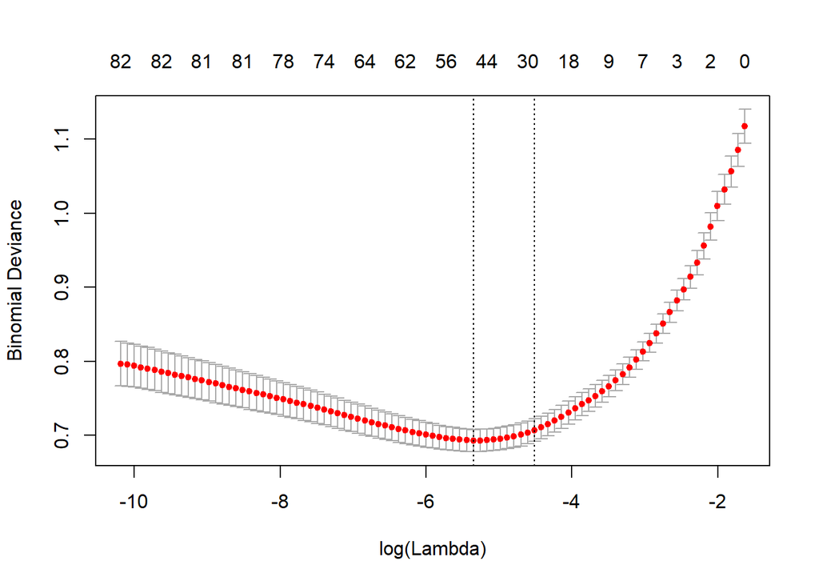

```r
adult <- read.csv("adult.csv", header = T, sep = ',', strip.white = T, stringsAsFactors = T)
adult_origin <- adult
adult <- adult %>%
    mutate(Salary = ifelse(Salary == ">50K", 1, 0))
adult <- dummy_cols(adult)

normalize <- function(x) {
    x <- as.matrix(x)
    minAttr=apply(x, 2, min)
    maxAttr=apply(x, 2, max)
    x <- sweep(x, 2, minAttr, FUN="-")
    x=sweep(x, 2,  maxAttr-minAttr, "/")
    return (x)
}

adult <- cbind(adult[16:111], adult[15])
adult <- cbind(normalize(adult_origin[,unlist(lapply(adult_origin, is.numeric))]), adult)

set.seed(123)

adult_train_test_split <- initial_split(adult, prop = 0.7)
adult_train_tbl <- training(adult_train_test_split)
adult_test_tbl <- testing(adult_train_test_split)

adult_vars_train <- adult_train_tbl[, c(names(adult[-103]))]
adult_vars_test <- adult_test_tbl[, c(names(adult[-103]))]

adult_target_train <- adult_train_tbl[, c("Salary")]
adult_target_test <- adult_test_tbl[, c("Salary")]

adult_cv_lasso = cv.glmnet(x = as.matrix(adult_vars_train), y = adult_target_train, alpha = 1, family="binomial")
plot(adult_cv_lasso)
```

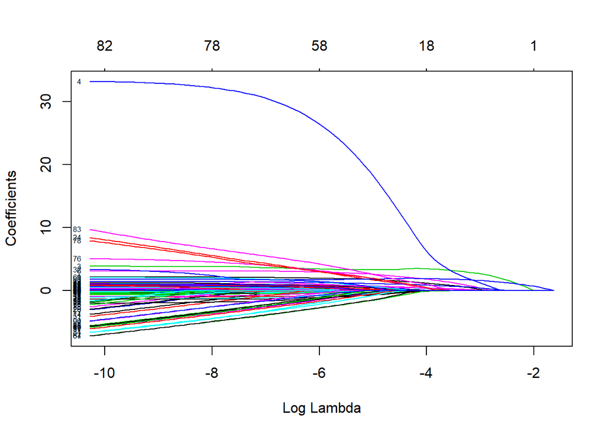

```r
plot(adult_cv_lasso$glmnet.fit, "lambda", label = T)
```

Some of the most important variables:

```r
coef(adult_cv_lasso, adult_cv_lasso$lambda.min)
```

```
## 103 x 1 sparse Matrix of class "dgCMatrix"
##                                                      1
## (Intercept)                               -6.884223033
## Age                                        1.825631041
## Fnlwgt                                     .
## Education_num                              3.265343862
## Captical_gain                             21.720385482
## Captial_loss                               0.779702282
## Hours_per_week                             2.734754202
## Workclass_State-gov                       -0.058133542
## Workclass_Self-emp-not-inc                -0.763283560
## Workclass_Private                          .
## Workclass_Federal-gov                      0.570790383
## Workclass_Local-gov                        .
## Workclass_?                                .
## Workclass_Self-emp-inc                     0.541050528
## Workclass_Without-pay                      .
## Education_Bachelors                        0.185285024
## Education_HS-grad                          .
## Education_11th                             .
## Education_Masters                         -0.175473601
## Education_9th                             -0.722696053
## Education_Some-college                    -0.005079326
## Education_Assoc-acdm                       0.155255123
## Education_Assoc-voc                        .
## Education_7th-8th                          .
## Education_Doctorate                        2.111262505
## Education_Prof-school                      .
## Education_5th-6th                          .
## Education_10th                             .
## Education_1st-4th                          .
## Education_Preschool                        .
## Education_12th                             .
## Marital_status_Never-married              -0.364122471
## Marital_status_Married-civ-spouse          1.757400271
## Marital_status_Divorced                    .
## Marital_status_Married-spouse-absent      -0.953386444
## Marital_status_Separated                  -0.034938710
## Marital_status_Married-AF-spouse           .
## Marital_status_Widowed                     0.280977420
```

[output cut: 50 more lines]

```
## Native_country_Haiti                      -0.241792944
## Native_country_Portugal                    0.960196863
## Native_country_Dominican-Republic          .
## Native_country_El-Salvador                 .
## Native_country_France                      .
## Native_country_Guatemala                   .
## Native_country_China                       .
## Native_country_Japan                      -0.304924985
## Native_country_Yugoslavia                  .
## Native_country_Peru                       -0.972466004
## Native_country_Outlying-US(Guam-USVI-etc)  .
## Native_country_Scotland                   -0.355490139
## Native_country_Trinadad&Tobago            -0.162489616
## Native_country_Greece                      .
## Native_country_Nicaragua                   .
```

For KNN, I calculate the auc for each predictor and the response variable `Salary`, and sort them from high auc to low auc.

```r
select.top.N.ROC <- function(response, predictors, data, n) {
    n <- min(n, length(predictors))
    aucs <- sapply(predictors, function(predictor) {
        auc(data[[response]], data[[predictor]])
    })
    return(predictors[order(aucs, decreasing=TRUE)][1:n])
}
top.variables <- select.top.N.ROC("Salary", names(adult[-103]), adult, 8)
```

Some of the most important variables:

```r
top.variables
```

```
## [1] "Marital_status_Married-civ-spouse" "Relationship_Husband"
## [3] "Education_num"                     "Age"
## [5] "Hours_per_week"                    "Sex_Male"
## [7] "Captical_gain"                     "Occupation_Exec-managerial"
```

Prove: the p-values are all less than 0.05, indicating all these predictors are statistically significant.

```r
adt_glm = glm(Salary ~ `Marital_status_Married-civ-spouse` + Relationship_Husband + Education_num + Age + Hours_per_week + Sex_Male + Captical_gain + `Occupation_Exec-managerial`, family = binomial, data = adult)
summary(adt_glm)
```

```
##
## Call:
## glm(formula = Salary ~ `Marital_status_Married-civ-spouse` +
##     Relationship_Husband + Education_num + Age + Hours_per_week +
##     Sex_Male + Captical_gain + `Occupation_Exec-managerial`,
##     family = binomial, data = adult)
##
## Deviance Residuals:
##      Min        1Q    Median        3Q       Max
## -2.60137  -0.55540  -0.23040  -0.05498   2.91132
##
## Coefficients:
##                                     Estimate Std. Error z value Pr(>|z|)
## (Intercept)                          -8.5803     0.5144 -16.680  < 2e-16
## `Marital_status_Married-civ-spouse`   3.1492     0.3057  10.302  < 2e-16
## Relationship_Husband                 -1.0720     0.3527  -3.039  0.00237
## Education_num                         4.8275     0.4612  10.468  < 2e-16
## Age                                   2.0980     0.4327   4.848 1.25e-06
## Hours_per_week                        3.4554     0.6028   5.732 9.93e-09
## Sex_Male                              0.6542     0.2830   2.312  0.02078
## Captical_gain                        26.8246     3.8458   6.975 3.06e-12
## `Occupation_Exec-managerial`          0.9413     0.1827   5.152 2.58e-07
##
## (Intercept)                         ***
## `Marital_status_Married-civ-spouse` ***
## Relationship_Husband                **
## Education_num                       ***
## Age                                 ***
## Hours_per_week                      ***
## Sex_Male                            *
## Captical_gain                       ***
## `Occupation_Exec-managerial`        ***
## ---
## Signif. codes:  0 '***' 0.001 '**' 0.01 '*' 0.05 '.' 0.1 ' ' 1
##
## (Dispersion parameter for binomial family taken to be 1)
##
##     Null deviance: 2246.6  on 1998  degrees of freedom
## Residual deviance: 1392.8  on 1990  degrees of freedom
## AIC: 1410.8
##
## Number of Fisher Scoring iterations: 7
```

**KNN model:**

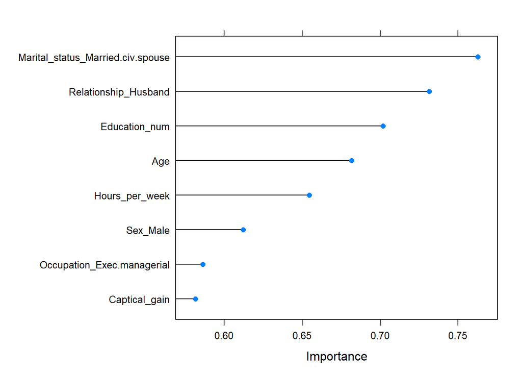

```r
salary_train_tbl <- adult_train_tbl
salary_test_tbl <- adult_test_tbl

salary_train_scaled <- data.frame(scale(salary_train_tbl[, c(top.variables)]))
salary_test_scaled <- data.frame(scale(salary_test_tbl[, c(top.variables)]))

df <- data.frame(scale(salary_train_tbl[, c(top.variables, "Salary")]))
df$Salary <- as.factor(df$Salary)

ctrl <- trainControl(method="repeatedcv", repeats = 3)
knnFit <- train(Salary ~ ., data = df, method = "knn", trControl = ctrl, preProcess = c("center","scale"),tuneLength = 20)
importance <- varImp(knnFit, scale = F)
plot(importance)
```

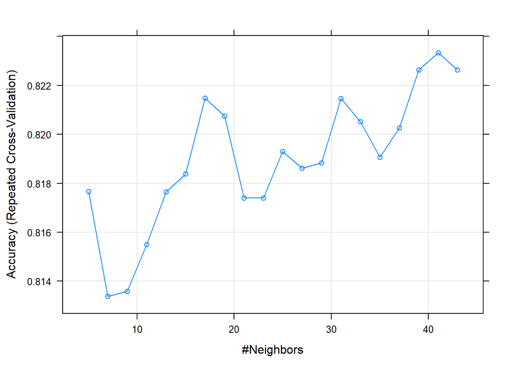

```r
plot(knnFit)
```

```r
knnFit
```

```
## k-Nearest Neighbors
##
## 1400 samples
##    8 predictor
##    2 classes: '-0.572746683877483', '1.74472544741869'
##
## Pre-processing: centered (8), scaled (8)
## Resampling: Cross-Validated (10 fold, repeated 3 times)
## Summary of sample sizes: 1260, 1260, 1261, 1260, 1260, 1260, ...
## Resampling results across tuning parameters:
##
##   k   Accuracy   Kappa
##    5  0.8176720  0.4846760
##    7  0.8133777  0.4699960
##    9  0.8135918  0.4708356
##   11  0.8154949  0.4748187
##   13  0.8176532  0.4759073
##   15  0.8183778  0.4734570
##   17  0.8214799  0.4789613
##   19  0.8207537  0.4741048
##   21  0.8174050  0.4630974
##   23  0.8173982  0.4627802
##   25  0.8193081  0.4693580
##   27  0.8186092  0.4662640
##   29  0.8188370  0.4694699
##   31  0.8214612  0.4749580
##   33  0.8205088  0.4691326
##   35  0.8190752  0.4633006
##   37  0.8202657  0.4613237
##   39  0.8226399  0.4661846
##   41  0.8233406  0.4668951
##   43  0.8226348  0.4641819
##
## Accuracy was used to select the optimal model using the largest value.
## The final value used for the model was k = 41.
```

```r
knnFit$bestTune[, 1]
```

```
## [1] 41
```

```r
nearest <- knn(train = salary_train_scaled, test = salary_test_scaled, cl = salary_train_tbl$Salary, k = knnFit$bestTune[, 1], prob = T)
nearest.train <- knn(train = salary_train_scaled, test = salary_train_scaled, cl = salary_train_tbl$Salary, k = knnFit$bestTune[, 1], prob = T)
```

## Question #2

- How do your models perform on training vs. testing data? Is your model overfit? How can you tell? Which techniques did you use to validate your model?
- Are you confident in your model? Why or why not?

**For LASSO model:**

I think my model is not overfit, because the MSE, the accuracy and the auc on training and testing are very close to each other.

And because the confidence interval is acceptable, I am confident in my model.

perform on training:

```r
lasso.pred.train = predict(adult_cv_lasso, s = adult_cv_lasso$lambda.min, newx = as.matrix(adult_vars_train))
mse_adult.train <- mean((lasso.pred.train - adult_train_tbl$Salary)^2)
mse_adult.train
```

```
## [1] 10.34286
```

```r
adult_train_tbl <- adult_train_tbl %>%
    mutate(P_TEST = predict(adult_cv_lasso, s = adult_cv_lasso$lambda.min, newx = as.matrix(adult_vars_train), type = "response")[, 1])

adults_roc <- roc(adult_train_tbl$Salary, adult_train_tbl$P_TEST)

nrow(adult_train_tbl[adult_train_tbl$Salary==0,])/nrow(adult_train_tbl)
```

```
## [1] 0.7528571
```

```r
p_train_quantiles <- quantile(adult_train_tbl$P_TEST, probs = seq(0, 1, 0.05), na.rm = FALSE, names = TRUE, type = 9)
p_train_quantiles
```

```
##           0%           5%          10%          15%          20%
## 0.0006642722 0.0048736001 0.0086346859 0.0143203160 0.0207163620
##          25%          30%          35%          40%          45%
## 0.0276150312 0.0362251101 0.0491895153 0.0671942130 0.0865366301
##          50%          55%          60%          65%          70%
## 0.1323840517 0.1774520719 0.2206793345 0.2716940660 0.3196848018
##          75%          80%          85%          90%          95%
## 0.3973407492 0.4882757092 0.5825991975 0.6991063099 0.8418454976
##         100%
## 0.9999999999
```

```r
threshold <- 0.3973407492
adult_train_tbl <- adult_train_tbl %>%
    mutate(P_RESP = ifelse(P_TEST >= threshold, 1, 0))

true_adults <- adult_train_tbl$Salary
predicted_adults <- adult_train_tbl$P_RESP

true_adults <- as.factor(true_adults)
predicted_adults <- as.factor(predicted_adults)
lasso.train.cfMatrix <- confusionMatrix(predicted_adults, true_adults)
lasso.train.cfMatrix
```

```
## Confusion Matrix and Statistics
##
##           Reference
## Prediction   0   1
##          0 953  97
##          1 101 249
##
##                Accuracy : 0.8586
##                  95% CI : (0.8392, 0.8764)
##     No Information Rate : 0.7529
##     P-Value [Acc > NIR] : <2e-16
##
##                   Kappa : 0.6214
##  Mcnemar's Test P-Value : 0.8312
##
##             Sensitivity : 0.9042
##             Specificity : 0.7197
##          Pos Pred Value : 0.9076
##          Neg Pred Value : 0.7114
##              Prevalence : 0.7529
##          Detection Rate : 0.6807
##    Detection Prevalence : 0.7500
##       Balanced Accuracy : 0.8119
##
##        'Positive' Class : 0
##
```

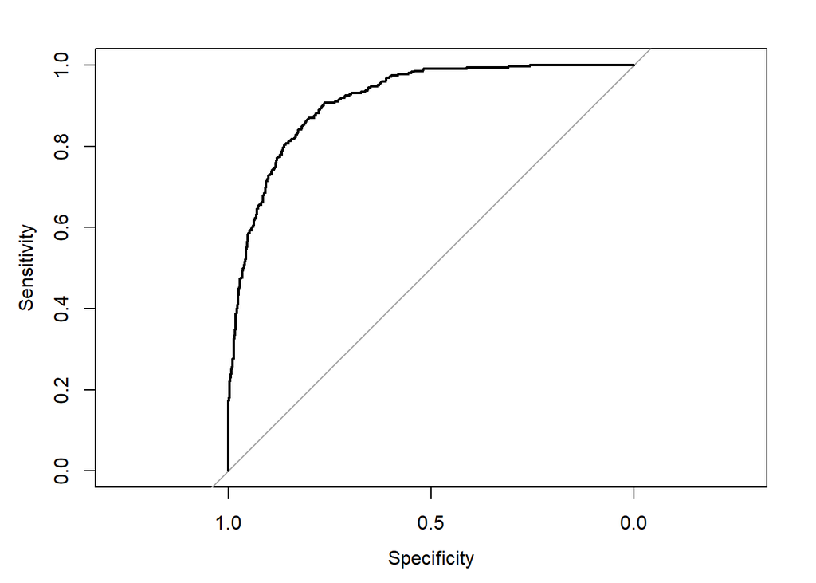

```r
adults_roc_plot <- plot(adults_roc)
```

```r
adults_auc <- auc(adults_roc)
adults_auc
```

```
## Area under the curve: 0.9144
```

```r
ci.auc(adults_auc)
```

```
## 95% CI: 0.8988-0.9299 (DeLong)
```

perform on testing:

```r
lasso.pred.test = predict(adult_cv_lasso, s = adult_cv_lasso$lambda.min, newx = as.matrix(adult_vars_test))
mse_adult.test <- mean((lasso.pred.test - adult_test_tbl$Salary)^2)
mse_adult.test
```

```
## [1] 11.20726
```

```r
adult_test_tbl_origin <- adult_test_tbl
adult_test_tbl <- adult_test_tbl %>%
    mutate(P_TEST = predict(adult_cv_lasso, s = adult_cv_lasso$lambda.min, newx = as.matrix(adult_vars_test), type = "response")[, 1])

adults_test_roc <- roc(adult_test_tbl$Salary, adult_test_tbl$P_TEST)

adult_test_tbl <- adult_test_tbl %>%
    mutate(P_RESP = ifelse(P_TEST >= threshold, 1, 0))
true_adults <- adult_test_tbl$Salary
predicted_adults <- adult_test_tbl$P_RESP

true_adults <- as.factor(true_adults)
predicted_adults <- as.factor(predicted_adults)
lasso.test.cfMatrix <- confusionMatrix(predicted_adults, true_adults)
lasso.test.cfMatrix
```

```
## Confusion Matrix and Statistics
##
##           Reference
## Prediction   0   1
##          0 394  54
##          1  52  99
##
##                Accuracy : 0.823
##                  95% CI : (0.7901, 0.8528)
##     No Information Rate : 0.7446
##     P-Value [Acc > NIR] : 3.074e-06
##
##                   Kappa : 0.5328
##  Mcnemar's Test P-Value : 0.9226
##
##             Sensitivity : 0.8834
##             Specificity : 0.6471
##          Pos Pred Value : 0.8795
##          Neg Pred Value : 0.6556
##              Prevalence : 0.7446
##          Detection Rate : 0.6578
##    Detection Prevalence : 0.7479
##       Balanced Accuracy : 0.7652
##
##        'Positive' Class : 0
##
```

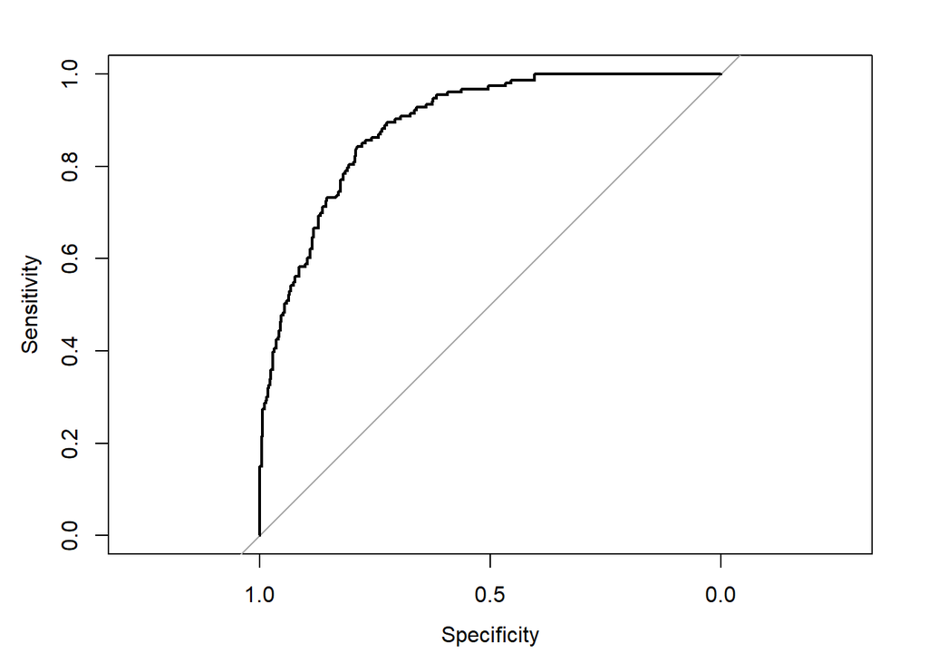

```r
adults_test_roc_plot <- plot(adults_test_roc)
```

```r
adults_test_auc <- auc(adults_test_roc)
adults_test_auc
```

```
## Area under the curve: 0.89
```

```r
ci.auc(adults_test_auc)
```

```
## 95% CI: 0.8632-0.9167 (DeLong)
```

**For KNN model:**

I think my model is not overfit, because the accuracy and AUC on training and testing are very close to each other.

And because the confidence interval is acceptable, I am confident in my model.

perform on training:

```r
salary_train_df <- data.frame(salary_train_tbl$Salary, nearest.train)
head(salary_train_df, n=20L)
```

```
##    salary_train_tbl.Salary nearest.train
## 1                        0             0
## 2                        0             0
## 3                        0             0
## 4                        0             0
## 5                        0             0
## 6                        1             1
## 7                        1             0
## 8                        1             1
## 9                        1             0
## 10                       0             0
## 11                       1             0
## 12                       0             0
## 13                       0             0
## 14                       0             0
## 15                       1             1
## 16                       0             0
## 17                       0             0
## 18                       0             0
## 19                       1             1
## 20                       1             0
```

```r
salary_train_df <- salary_train_df %>%
    mutate(CORRECT_KNN = ifelse(salary_train_df$salary_train_tbl.Salary == salary_train_df$nearest.train, 1, 0))

KNN_CORRECT <- sum(salary_train_df$CORRECT_KNN) / nrow(salary_train_df)
KNN_CORRECT
```

```
## [1] 0.8278571
```

```r
true_adt <- salary_train_df$salary_train_tbl.Salary
predicted_adt <- salary_train_df$nearest.train

true_adt <- as.factor(true_adt)
predicted_adt <- as.factor(predicted_adt)
knn.test.cfMatrix <- confusionMatrix(predicted_adt, true_adt)
knn.test.cfMatrix
```

```
## Confusion Matrix and Statistics
##
##           Reference
## Prediction   0   1
##          0 984 171
##          1  70 175
##
##                Accuracy : 0.8279
##                  95% CI : (0.807, 0.8473)
##     No Information Rate : 0.7529
##     P-Value [Acc > NIR] : 8.524e-12
##
##                   Kappa : 0.4871
##  Mcnemar's Test P-Value : 1.182e-10
##
##             Sensitivity : 0.9336
##             Specificity : 0.5058
##          Pos Pred Value : 0.8519
##          Neg Pred Value : 0.7143
##              Prevalence : 0.7529
##          Detection Rate : 0.7029
##    Detection Prevalence : 0.8250
##       Balanced Accuracy : 0.7197
##
##        'Positive' Class : 0
##
```

```r
prob <- attr(nearest.train, "prob")
prob <- ifelse(nearest.train == 0, 1-prob, prob)
df <- data.frame(salary_train_tbl$Salary, nearest.train, prob)
head(df, n=10L)
```

```
##    salary_train_tbl.Salary nearest.train       prob
## 1                        0             0 0.02439024
## 2                        0             0 0.31707317
## 3                        0             0 0.43902439
## 4                        0             0 0.29268293
## 5                        0             0 0.00000000
## 6                        1             1 0.75609756
## 7                        1             0 0.14634146
## 8                        1             1 0.83333333
## 9                        1             0 0.48780488
## 10                       0             0 0.02439024
```

```r
head(df[df$salary_train_tbl.Salary != df$nearest.train, ], n=10L)
```

```
##    salary_train_tbl.Salary nearest.train      prob
## 7                        1             0 0.1463415
## 9                        1             0 0.4878049
## 11                       1             0 0.2857143
## 20                       1             0 0.4878049
## 28                       1             0 0.1590909
## 29                       0             1 0.6086957
## 31                       0             1 0.6829268
## 40                       1             0 0.3414634
## 41                       1             0 0.3170732
## 44                       0             1 0.5365854
```

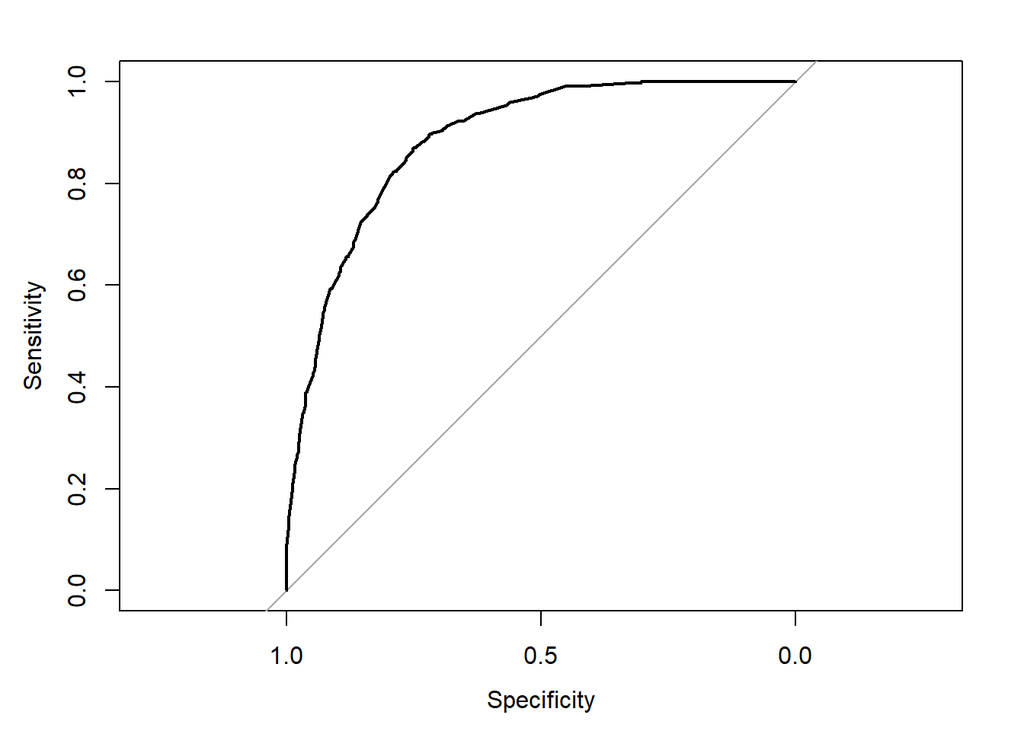

```r
nearest_train_roc_plot <- plot(roc(salary_train_tbl$Salary, prob))
```

```r
nearest_train_roc <- roc(salary_train_tbl$Salary, prob)
nearest_train_auc <- auc(nearest_train_roc)
nearest_train_auc
```

```
## Area under the curve: 0.8859
```

```r
ci.auc(nearest_train_auc)
```

```
## 95% CI: 0.8679-0.9038 (DeLong)
```

performing on testing:

```r
salary_test_df <- data.frame(salary_test_tbl$Salary, nearest)
head(salary_test_df, n = 20L)
```

```
##    salary_test_tbl.Salary nearest
## 1                       0       0
## 2                       0       1
## 3                       1       1
## 4                       0       0
## 5                       0       0
## 6                       1       0
## 7                       0       0
## 8                       0       0
## 9                       0       0
## 10                      0       0
## 11                      0       0
## 12                      0       0
## 13                      0       0
## 14                      1       0
## 15                      0       0
## 16                      0       0
## 17                      0       0
## 18                      1       1
## 19                      0       0
## 20                      0       0
```

```r
salary_test_df <- salary_test_df %>%
    mutate(CORRECT_KNN = ifelse(salary_test_df$salary_test_tbl.Salary == salary_test_df$nearest, 1, 0))

KNN_CORRECT <- sum(salary_test_df$CORRECT_KNN) / nrow(salary_test_df)
KNN_CORRECT
```

```
## [1] 0.8130217
```

```r
true_adt <- salary_test_df$salary_test_tbl.Salary
predicted_adt <- salary_test_df$nearest

true_adt <- as.factor(true_adt)
predicted_adt <- as.factor(predicted_adt)
knn.test.cfMatrix <-confusionMatrix(predicted_adt, true_adt)
knn.test.cfMatrix
```

```
## Confusion Matrix and Statistics
##
##           Reference
## Prediction   0   1
##          0 415  81
##          1  31  72
##
##                Accuracy : 0.813
##                  95% CI : (0.7794, 0.8435)
##     No Information Rate : 0.7446
##     P-Value [Acc > NIR] : 4.536e-05
##
##                   Kappa : 0.4493
##  Mcnemar's Test P-Value : 3.656e-06
##
##             Sensitivity : 0.9305
##             Specificity : 0.4706
##          Pos Pred Value : 0.8367
##          Neg Pred Value : 0.6990
##              Prevalence : 0.7446
##          Detection Rate : 0.6928
##    Detection Prevalence : 0.8280
##       Balanced Accuracy : 0.7005
##
##        'Positive' Class : 0
##
```

```r
prob <- attr(nearest, "prob")
prob <- ifelse(nearest == 0, 1-prob, prob)

df <- data.frame(salary_test_tbl$Salary, nearest, prob)
head(df, n=10L)
```

```
##    salary_test_tbl.Salary nearest       prob
## 1                       0       0 0.11904762
## 2                       0       1 0.80487805
## 3                       1       1 0.75609756
## 4                       0       0 0.09756098
## 5                       0       0 0.00000000
## 6                       1       0 0.31707317
## 7                       0       0 0.36363636
## 8                       0       0 0.00000000
## 9                       0       0 0.21951220
## 10                      0       0 0.07317073
```

```r
head(df[df$salary_test_tbl.Salary != df$nearest, ], n=10L)
```

```
##    salary_test_tbl.Salary nearest       prob
## 2                       0       1 0.80487805
## 6                       1       0 0.31707317
## 14                      1       0 0.35714286
## 22                      1       0 0.06976744
## 38                      0       1 0.60975610
## 40                      1       0 0.00000000
## 47                      1       0 0.36585366
## 52                      1       0 0.09756098
## 54                      0       1 0.60975610
## 57                      1       0 0.39024390
```

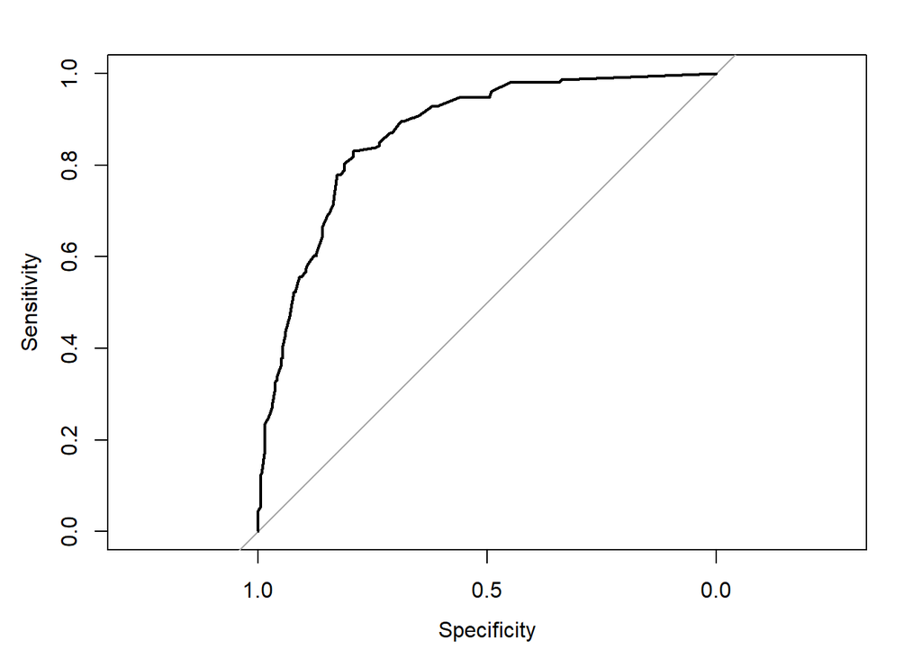

```r
nearest_test_roc_plot <- plot(roc(salary_test_tbl$Salary, prob))
```

```r
nearest_test_roc <- roc(salary_test_tbl$Salary, prob)
nearest_test_auc <- auc(nearest_test_roc)
nearest_test_auc
```

```
## Area under the curve: 0.8688
```

```r
ci.auc(nearest_test_auc)
```

```
## 95% CI: 0.8381-0.8996 (DeLong)
```

## Question #3

- Plot the ROC curves for both of your models.
- What is the AUC for your models? Which model performs better in terms of AUC?

**LASSO Model** performs better in terms of AUC.

For **LASSO Model**:

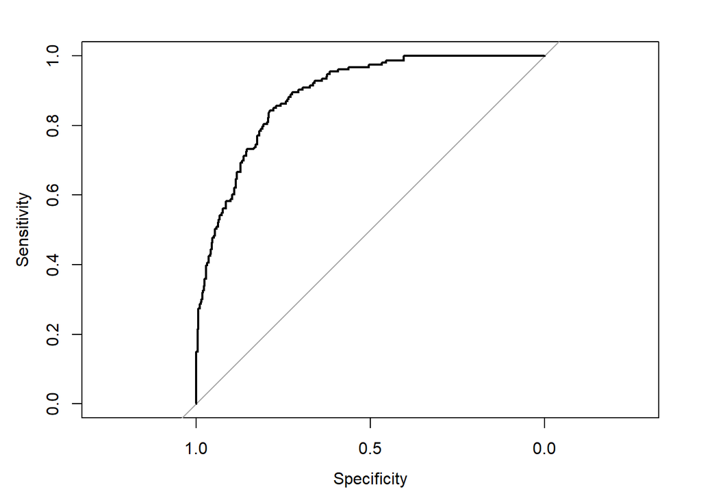

```r
plot(adults_test_roc_plot)
```

```r
adults_test_auc
```

```
## Area under the curve: 0.89
```

For **KNN Model**:

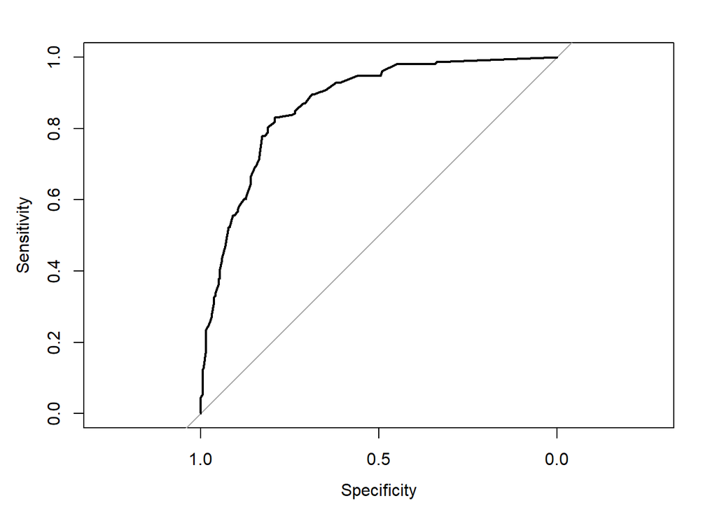

```r
plot(nearest_test_roc_plot)
```

```r
nearest_test_auc
```

```
## Area under the curve: 0.8688
```

## Question #4

- Create a confusion matrix on your testing data to and answer the following questions:
- What is the accuracy of your models?
- What is the precision of your model?
- What is the negative predictive value of your model?
- What is the sensitivity of your model?
- What is the specificity of your model?
- What is the F-1 score of your model?

For **LASSO Model**:

- accuracy: 0.823
- precision: 0.8795
- negative predictive value: 0.6556
- sensitivity: 0.8834
- specificity: 0.6471
- F-1 score: 2 * (0.8795 * 0.8834) / (0.8795 + 0.8834) = 0.8814457

```r
lasso.test.cfMatrix
```

```
## Confusion Matrix and Statistics
##
##           Reference
## Prediction   0   1
##          0 394  54
##          1  52  99
##
##                Accuracy : 0.823
##                  95% CI : (0.7901, 0.8528)
##     No Information Rate : 0.7446
##     P-Value [Acc > NIR] : 3.074e-06
##
##                   Kappa : 0.5328
##  Mcnemar's Test P-Value : 0.9226
##
##             Sensitivity : 0.8834
##             Specificity : 0.6471
##          Pos Pred Value : 0.8795
##          Neg Pred Value : 0.6556
##              Prevalence : 0.7446
##          Detection Rate : 0.6578
##    Detection Prevalence : 0.7479
##       Balanced Accuracy : 0.7652
##
##        'Positive' Class : 0
##
```

For **KNN Model**:

- accuracy: 0.813
- precision: 0.8367
- negative predictive value: 0.6990
- sensitivity: 0.9305
- specificity: 0.4706
- F-1 score: 2 * (0.8367 * 0.9305) / (0.8367 + 0.9305) = 0.8811106

```r
knn.test.cfMatrix
```

```
## Confusion Matrix and Statistics
##
##           Reference
## Prediction   0   1
##          0 415  81
##          1  31  72
##
##                Accuracy : 0.813
##                  95% CI : (0.7794, 0.8435)
##     No Information Rate : 0.7446
##     P-Value [Acc > NIR] : 4.536e-05
##
##                   Kappa : 0.4493
##  Mcnemar's Test P-Value : 3.656e-06
##
##             Sensitivity : 0.9305
##             Specificity : 0.4706
##          Pos Pred Value : 0.8367
##          Neg Pred Value : 0.6990
##              Prevalence : 0.7446
##          Detection Rate : 0.6928
##    Detection Prevalence : 0.8280
##       Balanced Accuracy : 0.7005
##
##        'Positive' Class : 0
##
```

## Question #5

- How did you choose your threshold for classification?

To choose best threshold, I tried two methods.

The first method: **use Youden’s J-statistic**

I use `coords` function to calculate the `max(sensitivities + specificities)`.

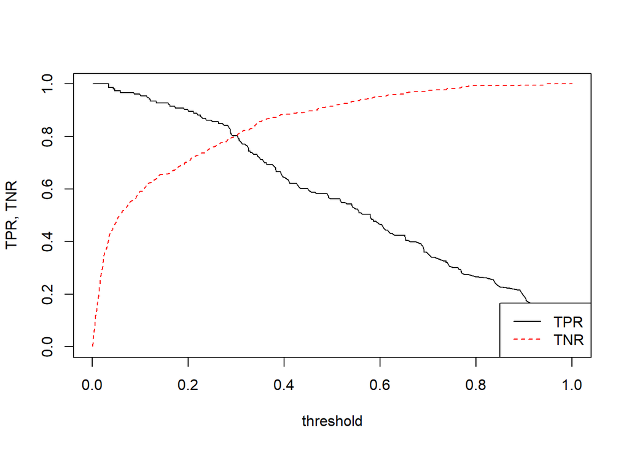

```r
matplot(data.frame(adults_test_roc$sensitivities, adults_test_roc$specificities), x = adults_test_roc$thresholds, type='l', xlab = 'threshold', ylab='TPR, TNR')
legend('bottomright', legend=c('TPR', 'TNR'), lty=1:2, col=1:2)
```

```r
coords(adults_test_roc, "best", "threshold", best.method = "youden")
```

```
##   threshold specificity sensitivity
##   0.2826108   0.7892377   0.8431373
```

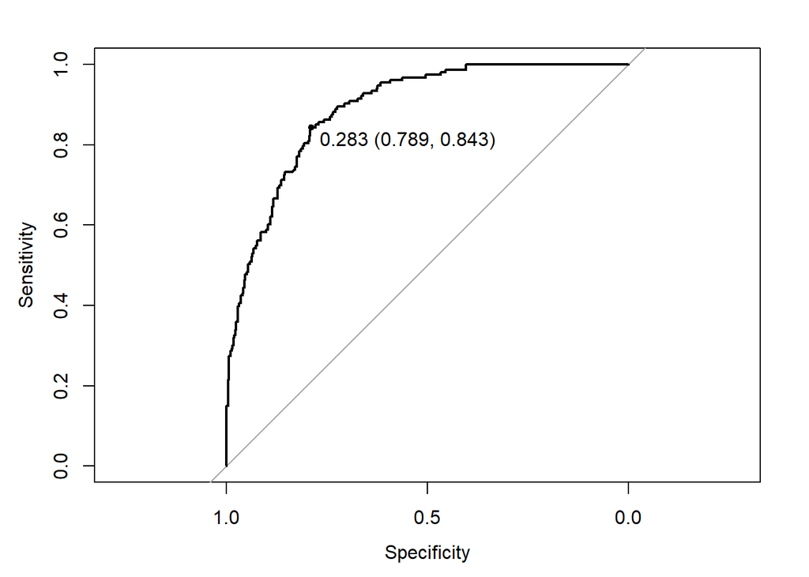

```r
plot(adults_test_roc, print.thres="best", print.thres.best.method="youden")
```

```r
adult_test_tbl.2 <- adult_test_tbl_origin
adult_test_tbl.2 <- adult_test_tbl.2 %>%
    mutate(P_TEST = predict(adult_cv_lasso, s = adult_cv_lasso$lambda.min, newx = as.matrix(adult_vars_test), type = "response")[, 1])

adults_test_roc <- roc(adult_test_tbl.2$Salary, adult_test_tbl.2$P_TEST)

adult_test_tbl.2 <- adult_test_tbl.2 %>%
    mutate(P_RESP = ifelse(P_TEST >= coords(adults_test_roc, "best", "threshold", best.method = "youden")[1], 1, 0))
true_adults <- adult_test_tbl.2$Salary
predicted_adults <- adult_test_tbl.2$P_RESP

true_adults <- as.factor(true_adults)
predicted_adults <- as.factor(predicted_adults)
confusionMatrix(predicted_adults, true_adults)
```

```
## Confusion Matrix and Statistics
##
##           Reference
## Prediction   0   1
##          0 352  24
##          1  94 129
##
##                Accuracy : 0.803
##                  95% CI : (0.7689, 0.8341)
##     No Information Rate : 0.7446
##     P-Value [Acc > NIR] : 0.0004586
##
##                   Kappa : 0.5498
##  Mcnemar's Test P-Value : 2.126e-10
##
##             Sensitivity : 0.7892
##             Specificity : 0.8431
##          Pos Pred Value : 0.9362
##          Neg Pred Value : 0.5785
##              Prevalence : 0.7446
##          Detection Rate : 0.5876
##    Detection Prevalence : 0.6277
##       Balanced Accuracy : 0.8162
##
##        'Positive' Class : 0
##
```

- accuracy: 0.803
- precision: 0.9362
- negative predictive value: 0.5785
- sensitivity: 0.7892
- specificity: 0.8431
- F-1 score: 2 * (0.9362 * 0.7892) / (0.9362 + 0.7892) = 0.856438

The second method: **use quantile()**

I calculate the ratio of category ‘0’, and the proportion of P_TEST of the training dataset, and make comparison between them.

```r
nrow(adult_train_tbl[adult_train_tbl$Salary==0,])/nrow(adult_train_tbl)
```

```
## [1] 0.7528571
```

```r
p_train_quantiles
```

```
##           0%           5%          10%          15%          20%
## 0.0006642722 0.0048736001 0.0086346859 0.0143203160 0.0207163620
##          25%          30%          35%          40%          45%
## 0.0276150312 0.0362251101 0.0491895153 0.0671942130 0.0865366301
##          50%          55%          60%          65%          70%
## 0.1323840517 0.1774520719 0.2206793345 0.2716940660 0.3196848018
##          75%          80%          85%          90%          95%
## 0.3973407492 0.4882757092 0.5825991975 0.6991063099 0.8418454976
##         100%
## 0.9999999999
```

The 75% of p_train_quantiles is 0.3973407492. (The variables below were calculated in the content above, in Question #2)

```r
threshold
```

```
## [1] 0.3973407
```

And use the same threshold for the testing dataset (shown in Question #2).

```r
lasso.test.cfMatrix
```

```
## Confusion Matrix and Statistics
##
##           Reference
## Prediction   0   1
##          0 394  54
##          1  52  99
##
##                Accuracy : 0.823
##                  95% CI : (0.7901, 0.8528)
##     No Information Rate : 0.7446
##     P-Value [Acc > NIR] : 3.074e-06
##
##                   Kappa : 0.5328
##  Mcnemar's Test P-Value : 0.9226
##
##             Sensitivity : 0.8834
##             Specificity : 0.6471
##          Pos Pred Value : 0.8795
##          Neg Pred Value : 0.6556
##              Prevalence : 0.7446
##          Detection Rate : 0.6578
##    Detection Prevalence : 0.7479
##       Balanced Accuracy : 0.7652
##
##        'Positive' Class : 0
##
```

- accuracy: 0.823
- precision: 0.8795
- negative predictive value: 0.6556
- sensitivity: 0.8834
- specificity: 0.6471
- F-1 score: 2 * (0.8795 * 0.8834) / (0.8795 + 0.8834) = 0.8814457

The first method has the maximum of sensitivity plus specificity, while the second method has the higher accuracy and higher F-1 score. In my model, I choose the threshold in the **second method**.

- Based on question 4, what are some good things about your model? What are some limitations of your model?

Good things: high F-1 score, high AUC

Limitations: both accuracies are only around 0.8, both have low Negative Predictive Values